# R markdown to accompany *Time modulates trophic dispersion and displacement in lake food webs*

Charles Wainright

October 1, 2020

## Introduction

This R markdown accompanies the journal article titled *Time modulates trophic dispersion and displacement in lake food webs* (hereafter called “the article”). The purpose of this R markdown is to explain analyses included in the article and enhance reproducibility of these techniques. Questions regarding this analysis or the R markdown should be directed to Charles Wainright at charles_wainright@fws.gov.

```r
library(ggplot2)
library(dplyr)
library(ellipse)
library(gridExtra)
library(rjags)
library(hdrcde)
library(reshape2)
library(tidyr)
library(cowplot)
library(lme4)
library(effects)
library(lmerTest)
library(SIBER)
library(DataCombine)
library(tidyverse)
library(Hmisc)
library(nicheROVER)
library(MixSIAR)
library(cowplot)
library(knitr)
```

### Dataset overview

Our dataset has 47 columns and 1459 rows. Each row represents one isotope sample. There are 10 lakes and 437 fish samples in this dataset.

```r
length(isotope_dataset) #count of columns (variables)
```

```
## [1] 47
```

```r
length(isotope_dataset$d13C) #count of rows (samples)
```

```
## [1] 1459
```

```r
length(unique(isotope_dataset$Lake_name)) #count of lakes
```

```
## [1] 10
```

```r
length(subset(isotope_dataset,Sample_type=="Fish")$d13C) #count of fish samples
```

```
## [1] 437
```

The 4 columns included in the overview below (Table 1) show the most important features of the dataset, including lake name, the scientific name of the organism associated with each sample, and the absolute $\delta$<sup>13</sup>C and $\delta$<sup>15</sup>N for each sample.

```r
data <- subset(isotope_dataset, select=c(Lake_name,Scientific_name,d13C,d15N))
colnames(data)[1] <- "Lake name"
colnames(data)[2] <- "Scientific name"
colnames(data)[3] <- "$\\delta$^13^C ($\\unicode{x2030}$)"
colnames(data)[4] <- "$\\delta$^15^N ($\\unicode{x2030}$)"
library(knitr)
kable(head(data), align="llcc", caption = "Table 1. Dataset overview.")
```

Table 1. Dataset overview.

| Lake name | Scientific name | $\delta$<sup>13</sup>C ($\unicode{x2030}$) | $\delta$<sup>15</sup>N ($\unicode{x2030}$) |
| --- | --- | --- | --- |
| Big Salmon | Naididae | -19.73 | 1.32 |
| Big Salmon | Salvelinus confluentus | -29.77 | 11.11 |
| Big Salmon | Lestidae | -26.35 | 3.39 |
| Big Salmon | Lestidae | -26.58 | 4.01 |
| Big Salmon | Periphyton | -20.81 | 0.62 |
| Big Salmon | Salvelinus confluentus | -28.13 | 10.24 |

### Trophic baseline selection

Our first goal was to account for spatial and temporal isotopic variability among our study lakes (Post 2002, Guzzo et al 2011) by selecting the best $\delta$<sup>13</sup>C and $\delta$<sup>15</sup>N isotopic baseline. To accomplish this goal, we measured $\delta$<sup>13</sup>C and $\delta$<sup>15</sup>N variability among primary consumers in our study system and then chose the least variable consumer (Syvaranta and Jones 2009) for later isotopic baseline corrections. Since standard error scales inversely with sample size, we started with our dataset’s most abundant invertebrates and periphyton as trophic baseline candidates. These candidates included mayflies (Ephemeroptera: Baetidae, Leptophlebiidae, Heptageniidae, and Ephemerellidae), lithophytic periphyton from 0.5 m depth, caddisflies (Trichoptera: Limnephilidae and Leptoceridae), water mites (Hydrachnidia), bulk zooplankton from 10 m depth, and snails (Gastropoda: Physidae, Lynmaeidae, Planorbidae).

The following code chunks summarize how we selected a trophic baseline for our study lakes. First, we calculated within-lake $\delta$<sup>13</sup>C and $\delta$<sup>15</sup>N variability for each candidate. We provide periphyton as an example of how within-lake $\delta$<sup>13</sup>C and $\delta$<sup>15</sup>N variability was determined for each trophic baseline candidate (Table 2).

```r
####################################################################
#Periphyton summary
####################################################################
isotope_dataset <- read.csv("C:/Users/wainr/Documents/nature_08132020/final_datasets/isotope_dataset_MT_lake_trout_food_web_09102020.csv", header=TRUE)
data <- isotope_dataset
data <- data[c("Lake_name","real.name","d13C","d15N")] #$real.name is for convenience because it uses scientific name for invertebrates but uses common name for fish
data <- subset(data,data$real.name%in%c("Periphyton"))
#write summary function
#summary function based on: https://github.com/clquezada/tRophicPosition/blob/master/R/summariseIsotopeData.R
summariseIsotopeData <- function (df = NULL, grouping = c("Lake_name", "real.name"),
                                  printSummary = FALSE, ...){

  d13C <- d15N <- NULL

  if (is.null(checkmate::checkNames(df, c("d13C", "d15N", grouping))))
    stop("Check the grouping variable or the names in your dataframe")

  summary <- plyr::ddply(df, grouping, plyr::summarise,
                         n = length(d13C),
                         mean_d13C = mean(d13C),
                         sd_d13C = sd(d13C),
                         se_d13C = sqrt(var(d13C)/length(d13C)),
                         mean_d15N = mean(d15N),
                         sd_d15N = sd(d15N),
                         se_d15N = sqrt(var(d15N)/length(d15N))
  )
 if (printSummary)  print(summary)
  summary
  return(summary)
}
#create summary dataframe using function and grouping specified above
periphyton_isotope_summary<-summariseIsotopeData(df = subset(data),
                                                   grouping = c("Lake_name", "real.name"))
#round numbers
periphyton_isotope_summary$mean_d13C <- round(periphyton_isotope_summary$mean_d13C,2)
periphyton_isotope_summary$se_d13C <- round(periphyton_isotope_summary$se_d13C,2)
periphyton_isotope_summary$mean_d15N <- round(periphyton_isotope_summary$mean_d15N,2)
periphyton_isotope_summary$se_d15N <- round(periphyton_isotope_summary$se_d15N,2)
periphyton_isotope_summary<-subset(periphyton_isotope_summary,select=-c(sd_d13C,sd_d15N))
#re-name columns
colnames(periphyton_isotope_summary)[1] <- "Lake name"
colnames(periphyton_isotope_summary)[2] <- "Candidate"
colnames(periphyton_isotope_summary)[4] <- "Mean $\\delta$^13^C ($\\unicode{x2030}$)"
colnames(periphyton_isotope_summary)[5] <- "SE $\\delta$^13^C ($\\unicode{x2030}$)"
colnames(periphyton_isotope_summary)[6] <- "Mean $\\delta$^15^N ($\\unicode{x2030}$)"
colnames(periphyton_isotope_summary)[7] <- "SE $\\delta$^15^N ($\\unicode{x2030}$)"
#make table
library(knitr)
kable(periphyton_isotope_summary, align="lcccccc", caption = "Table 2. Within-lake isotopic variability of periphyton.")
```

Table 2. Within-lake isotopic variability of periphyton.

| Lake name | Candidate | n | Mean $\delta$<sup>13</sup>C ($\unicode{x2030}$) | SE $\delta$<sup>13</sup>C ($\unicode{x2030}$) | Mean $\delta$<sup>15</sup>N ($\unicode{x2030}$) | SE $\delta$<sup>15</sup>N ($\unicode{x2030}$) |
| --- | --- | --- | --- | --- | --- | --- |
| Big Salmon | Periphyton | 5 | -20.33 | 0.60 | 0.34 | 0.09 |
| Bowman | Periphyton | 5 | -19.53 | 0.17 | 0.49 | 0.16 |
| Hungry Horse | Periphyton | 5 | -23.20 | 0.51 | 0.16 | 0.21 |
| Kintla | Periphyton | 5 | -29.78 | 0.53 | -0.87 | 0.15 |
| Lindbergh | Periphyton | 5 | -22.69 | 0.98 | 0.12 | 0.20 |
| Logging | Periphyton | 10 | -19.39 | 1.32 | 0.29 | 0.35 |
| McDonald | Periphyton | 5 | -24.08 | 0.78 | -0.33 | 0.11 |
| Quartz | Periphyton | 10 | -19.23 | 0.90 | -0.68 | 0.15 |
| Swan | Periphyton | 5 | -24.39 | 0.03 | 2.34 | 0.17 |
| Trout | Periphyton | 6 | -21.64 | 0.93 | 0.48 | 0.21 |

We repeated the within-lake variability process for each trophic baseline candidate. Then, we took the mean of each candidate’s within-lake $\delta$<sup>13</sup>C and $\delta$<sup>15</sup>N standard error to determine its among-lake isotopic variability. We repeated this process to determine among-lake $\delta$<sup>13</sup>C and $\delta$<sup>15</sup>N variability for each candidate (Table 3). Among-lake isotopic variability was the basis for our trophic baseline selection because among-lake isotopic variability tells us which trophic baseline candidate had the most consistent $\delta$<sup>13</sup>C and $\delta$<sup>15</sup>N signatures and, therefore, which candidate’s sample mean ($\bar{x}$) is most likely to be nearest to its population mean ($\mu$).

Next, we produced a table of $\delta$<sup>13</sup>C and $\delta$<sup>15</sup>N mean standard error (se) for each trophic baseline candidate in each lake, to determine which candidate had the lowest among-lake isotopic variability. This summary is provided below (Table 3) and in the article’s SI Table 5.

```r
####################################################################
#make comparison table, SI Table 5
####################################################################

compare <- data.frame(Candidate=c("Periphyton","Mayfly","Zooplankton","Caddisfly","Hydrachnidia","Snail"),
                      n=rep(NA,6),
                      mean_d13C_base_se=rep(NA,6),
                      mean_d15N_base_se=rep(NA,6))
#n
compare$n[1] <- sum(periphyton_isotope_summary$n)
compare$n[2] <- sum(mayfly_lookup$n_base)
compare$n[3] <- sum(zooplankton_isotope_summary$n)
compare$n[4] <- sum(caddis_lookup$n_base)
compare$n[5] <- sum(hydrachnidia_isotope_summary$n)
compare$n[6] <- sum(snail_lookup$n)
#d13C_se
compare$mean_d13C_base_se[1] <- mean(periphyton_isotope_summary$se_d13C)
compare$mean_d13C_base_se[2] <- mean(mayfly_lookup$d13C_base_se)
compare$mean_d13C_base_se[3] <- mean(zooplankton_isotope_summary$se_d13C)
compare$mean_d13C_base_se[4] <- mean(caddis_lookup$d13C_base_se)
compare$mean_d13C_base_se[5] <- mean(hydrachnidia_isotope_summary$se_d13C)
compare$mean_d13C_base_se[6] <- mean(snail_lookup$d13C_base_se)
compare$mean_d13C_base_se <- round(compare$mean_d13C_base_se,2)
#d15N_se
compare$mean_d15N_base_se[1] <- mean(periphyton_isotope_summary$se_d15N)
compare$mean_d15N_base_se[2] <- mean(mayfly_lookup$d15N_base_se)
compare$mean_d15N_base_se[3] <- mean(zooplankton_isotope_summary$se_d15N)
compare$mean_d15N_base_se[4] <- mean(caddis_lookup$d15N_base_se)
compare$mean_d15N_base_se[5] <- mean(hydrachnidia_isotope_summary$se_d15N)
compare$mean_d15N_base_se[6] <- mean(snail_lookup$d15N_base_se)
compare$mean_d15N_base_se <- round(compare$mean_d15N_base_se,2)
#re-name columns
colnames(compare)[3] <- "Mean $\\delta$^15^N SE ($\\unicode{x2030}$)"
colnames(compare)[4] <- "Mean $\\delta$^15^N SE ($\\unicode{x2030}$)"
#make table
library(knitr)
kable(compare, align="lccc", caption = "Table 3. Among-lake isotopic variability for all isotope baseline candidates.")
```

Table 3. Among-lake isotopic variability for all isotope baseline candidates.

| Candidate | n | Mean $\delta$<sup>15</sup>N SE ($\unicode{x2030}$) | Mean $\delta$<sup>15</sup>N SE ($\unicode{x2030}$) |
| --- | --- | --- | --- |
| Periphyton | 61 | 0.68 | 0.18 |
| Mayfly | 135 | 0.55 | 0.22 |
| Zooplankton | 52 | 1.12 | 0.37 |
| Caddisfly | 88 | 0.69 | 0.30 |
| Hydrachnidia | 42 | 0.68 | 0.43 |
| Snail | 54 | 0.89 | 0.17 |

For subsequent isotope analyses, we used mayflies (Ephemeroptera: Baetidae, Leptophlebiidae, Heptageniidae, and Ephemerellidae) as our lake-specific trophic baselines because mayflies had the most consistent isotope signature of any isotope baseline candidate (Table 3, lowest standard error; Article’s SI Table 5). Mayflies are a common choice for isotope baseline in rivers (e.g., Jardine et. al., 2014; Rogosch and Olden, 2020) and can be used as $\delta$<sup>13</sup>C and $\delta$<sup>15</sup>N baselines in lakes (Vander Zanden and Rasmussen, 1999; de Eyto et. al., 2020). Therefore, mayflies were the best available choice for trophic baseline in this study.

### SI Table 2, lake summary table

With mayflies selected as the trophic baseline, we added lake-specific mayfly $\delta$<sup>13</sup>C and $\delta$<sup>15</sup>N baselines to a table summarizing lake characteristics. The final result was Table 4 (Article’s SI Table 2).

Lake summary table:

```r
#########################################################################################################
#Lake table
#########################################################################################################
#load data
isotope_dataset <- read.csv("C:/Users/wainr/Documents/nature_08132020/final_datasets/isotope_dataset_MT_lake_trout_food_web_11072020.csv", header=TRUE)

#write summary function
#summary function based on: https://github.com/clquezada/tRophicPosition/blob/master/R/summariseIsotopeData.R
summariseIsotopeData <- function (df = NULL, grouping = c("Lake_name"),
                                  printSummary = FALSE, ...){

  d13C <- d15N <- NULL

  if (is.null(checkmate::checkNames(df, c("d13C", "d15N", grouping))))
    stop("Check the grouping variable or the names in your dataframe")

  summary <- plyr::ddply(df, grouping, plyr::summarise,
                         Lake_surface_elev_m = mean(Lake_surface_elev_m),
                         Surface_area_ha = mean(Surface_area_ha),
                         Lake_max_depth_m = mean(Lake_max_depth_m),
                         Secchi_m = mean(Secchi_m),
                         Current_conversion = mean(Current_conversion)

  )

  if (printSummary)  print(summary)

  summary
  return(summary)
}

#create summary dataframe using function and grouping specified above
isotope_summary_df<-summariseIsotopeData(df = subset(isotope_dataset),
                                         grouping = c("Lake_name"))
head(isotope_summary_df)
```

```
##      Lake_name Lake_surface_elev_m Surface_area_ha Lake_max_depth_m
## 1   Big Salmon                1340             393               42
## 2       Bowman                1228             910               77
## 3 Hungry Horse                1112            9630              149
## 4       Kintla                1221            1039              120
## 5    Lindbergh                1369             329               36
## 6      Logging                1161             581               60
##   Secchi_m Current_conversion
## 1     9.33               0.00
## 2    13.33               0.91
## 3     4.33               0.00
## 4    14.33               0.98
## 5     7.33               0.86
## 6     7.33               0.78
```

```r
##NOT RUN but useful
#use binomial linear regression coefficients to calculate modelled "timestep" for each lake
#isotope_summary_df$prop <- isotope_summary_df$Current_conversion/(1-isotope_summary_df$Current_conversion) #for use in logit link function
#isotope_summary_df$log <- log10(isotope_summary_df$prop) #logit link function
#isotope_summary_df$Time <- (isotope_summary_df$log+1.97331)/.09127 #binomial linear regression coefficients (calculated in Figure 7, below)
#isotope_summary_df$Model_timestep <- isotope_summary_df$Time+15 # "detection period" (lim yhat -> 0) calculated based on binomial linear regression
```

Isotopic baseline table:

```r
#########################################################################################################
#Isotopic baselines for lake table
#########################################################################################################
lookup <- data.frame(Lake_name=c("Big  Salmon","Bowman","Kintla","Trout","Logging","Quartz","Hungry Horse","McDonald","Swan","Lindbergh"),
                     n_base=rep(NA,10),
                     d13C_baseline=rep(NA,10),
                     d13C_base_se=rep(NA,10),
                     d15N_baseline=rep(NA,10),
                     d15N_base_se=rep(NA,10)) #empty dataframe to receive calculated values

isotope_dataset <- read.csv("C:/Users/wainr/Documents/nature_08132020/final_datasets/isotope_dataset_MT_lake_trout_food_web_11072020.csv", header=TRUE)
#1/10: Big salmon
data <- isotope_dataset
data <- subset(data,data$Lake_name=="Big Salmon")
data <- subset(data,data$real.name%in%c("Baetidae","Leptophlebiidae","Heptageniidae","Ephemerellidae"))
lookup$n_base[1] <- length(data$real.name)
lookup$d13C_baseline[1] <- mean(data$d13C)
lookup$d13C_base_se[1] <- sqrt(var(data$d13C)/length(data$d13C))
lookup$d15N_baseline[1] <- mean(data$d15N)
lookup$d15N_base_se[1] <- sqrt(var(data$d15N)/length(data$d15N))
#2/10: Bowman
data <- isotope_dataset
data <- subset(data,data$Lake_name=="Bowman")
data <- subset(data,data$real.name%in%c("Baetidae","Leptophlebiidae","Heptageniidae","Ephemerellidae"))
lookup$n_base[2] <- length(data$real.name)
lookup$d13C_baseline[2] <- mean(data$d13C)
lookup$d13C_base_se[2] <- sqrt(var(data$d13C)/length(data$d13C))
lookup$d15N_baseline[2] <- mean(data$d15N)
lookup$d15N_base_se[2] <- sqrt(var(data$d15N)/length(data$d15N))
#3/10: Kintla
data <- isotope_dataset
data <- subset(data,data$Lake_name=="Kintla")
data <- subset(data,data$real.name%in%c("Baetidae","Leptophlebiidae","Heptageniidae","Ephemerellidae"))
lookup$n_base[3] <- length(data$real.name)
lookup$d13C_baseline[3] <- mean(data$d13C)
lookup$d13C_base_se[3] <- sqrt(var(data$d13C)/length(data$d13C))
lookup$d15N_baseline[3] <- mean(data$d15N)
lookup$d15N_base_se[3] <- sqrt(var(data$d15N)/length(data$d15N))
#4/10: Trout
data <- isotope_dataset
data <- subset(data,data$Lake_name=="Trout")
data <- subset(data,data$real.name%in%c("Baetidae","Leptophlebiidae","Heptageniidae","Ephemerellidae"))
lookup$n_base[4] <- length(data$real.name)
lookup$d13C_baseline[4] <- mean(data$d13C)
lookup$d13C_base_se[4] <- sqrt(var(data$d13C)/length(data$d13C))
lookup$d15N_baseline[4] <- mean(data$d15N)
lookup$d15N_base_se[4] <- sqrt(var(data$d15N)/length(data$d15N))
#5/10: Logging
data <- isotope_dataset
data <- subset(data,data$Lake_name=="Logging")
data <- subset(data,data$real.name%in%c("Baetidae","Leptophlebiidae","Heptageniidae","Ephemerellidae"))
lookup$n_base[5] <- length(data$real.name)
lookup$d13C_baseline[5] <- mean(data$d13C)
lookup$d13C_base_se[5] <- sqrt(var(data$d13C)/length(data$d13C))
lookup$d15N_baseline[5] <- mean(data$d15N)
lookup$d15N_base_se[5] <- sqrt(var(data$d15N)/length(data$d15N))
#6/10: Quartz
data <- isotope_dataset
data <- subset(data,data$Lake_name=="Quartz")
data <- subset(data,data$real.name%in%c("Baetidae","Leptophlebiidae","Heptageniidae","Ephemerellidae"))
lookup$n_base[6] <- length(data$real.name)
lookup$d13C_baseline[6] <- mean(data$d13C)
lookup$d13C_base_se[6] <- sqrt(var(data$d13C)/length(data$d13C))
lookup$d15N_baseline[6] <- mean(data$d15N)
lookup$d15N_base_se[6] <- sqrt(var(data$d15N)/length(data$d15N))
#7/10: Hungry Horse
data <- isotope_dataset
data <- subset(data,data$Lake_name=="Hungry Horse")
data <- subset(data,data$real.name%in%c("Baetidae","Leptophlebiidae","Heptageniidae","Ephemerellidae"))
lookup$n_base[7] <- length(data$real.name)
lookup$d13C_baseline[7] <- mean(data$d13C)
lookup$d13C_base_se[7] <- sqrt(var(data$d13C)/length(data$d13C))
lookup$d15N_baseline[7] <- mean(data$d15N)
lookup$d15N_base_se[7] <- sqrt(var(data$d15N)/length(data$d15N))
#8/10: McDonald
data <- isotope_dataset
data <- subset(data,data$Lake_name=="McDonald")
data <- subset(data,data$real.name%in%c("Baetidae","Leptophlebiidae","Heptageniidae","Ephemerellidae"))
lookup$n_base[8] <- length(data$real.name)
lookup$d13C_baseline[8] <- mean(data$d13C)
lookup$d13C_base_se[8] <- sqrt(var(data$d13C)/length(data$d13C))
lookup$d15N_baseline[8] <- mean(data$d15N)
lookup$d15N_base_se[8] <- sqrt(var(data$d15N)/length(data$d15N))
#9/10: Swan
data <- isotope_dataset
data <- subset(data,data$Lake_name=="Swan")
data <- subset(data,data$real.name%in%c("Baetidae","Leptophlebiidae","Heptageniidae","Ephemerellidae"))
lookup$n_base[9] <- length(data$real.name)
lookup$d13C_baseline[9] <- mean(data$d13C)
lookup$d13C_base_se[9] <- sqrt(var(data$d13C)/length(data$d13C))
lookup$d15N_baseline[9] <- mean(data$d15N)
lookup$d15N_base_se[9] <- sqrt(var(data$d15N)/length(data$d15N))
#10/10: Lindbergh
data <- isotope_dataset
data <- subset(data,data$Lake_name=="Lindbergh")
data <- subset(data,data$real.name%in%c("Baetidae","Leptophlebiidae","Heptageniidae","Ephemerellidae"))
lookup$n_base[10] <- length(data$real.name)
lookup$d13C_baseline[10] <- mean(data$d13C)
lookup$d13C_base_se[10] <- sqrt(var(data$d13C)/length(data$d13C))
lookup$d15N_baseline[10] <- mean(data$d15N)
lookup$d15N_base_se[10] <- sqrt(var(data$d15N)/length(data$d15N))

head(lookup) #lake-specific isotopic baselines
```

```
##     Lake_name n_base d13C_baseline d13C_base_se d15N_baseline d15N_base_se
## 1 Big  Salmon      7     -23.25571    1.0904190     0.7800000    0.1434108
## 2      Bowman     15     -28.27600    0.2563773     0.9640000    0.3102914
## 3      Kintla     10     -27.16200    0.4533108     0.4690000    0.2202547
## 4       Trout     15     -23.84733    0.5485396     1.0380000    0.1541496
## 5     Logging     15     -21.15200    0.7843318     0.9853333    0.1797137
## 6      Quartz     15     -23.41800    0.4820563     1.0513333    0.2195404
```

```r
#########################################################################################################
#Combine lake table and isotopic baseline tables. SI Table 2.
#########################################################################################################
SI_table_2 <- merge(isotope_summary_df,lookup,by.x="Lake_name",by.y="Lake_name") #combine
SI_table_2$d13C_baseline <- round(SI_table_2$d13C_baseline,2) #round
SI_table_2$d15N_baseline <- round(SI_table_2$d15N_baseline,2) #round
SI_table_2 <- subset(SI_table_2,select=-c(n_base,d13C_base_se,d15N_base_se))
#re-name columns
colnames(SI_table_2)[1] <- "Lake name"
colnames(SI_table_2)[2] <- "Surface elev (m)"
colnames(SI_table_2)[3] <- "Surface area (ha)"
colnames(SI_table_2)[4] <- "Max depth (m)"
colnames(SI_table_2)[5] <- "Secchi (m)"
colnames(SI_table_2)[6] <- "Current conversion"
colnames(SI_table_2)[7] <- "Baseline <br> $\\delta$^13^C ($\\unicode{x2030}$)"
colnames(SI_table_2)[8] <- "Baseline <br> $\\delta$^15^N ($\\unicode{x2030}$)"
#make table
library(knitr)
kable(SI_table_2, align="lcccccc", caption = "Table 4. Lake summary table with isotopic baselines added (Article's SI Table 2).")
```

Table 4. Lake summary table with isotopic baselines added (Article’s SI Table 2).

| Lake name | Surface elev (m) | Surface area (ha) | Max depth (m) | Secchi (m) | Current conversion | Baseline $\delta$<sup>13</sup>C ($\unicode{x2030}$) | Baseline $\delta$<sup>15</sup>N ($\unicode{x2030}$) |
| --- | --- | --- | --- | --- | --- | --- | --- |
| Bowman | 1228 | 910 | 77 | 13.33 | 0.91 | -28.28 | 0.96 |
| Hungry Horse | 1112 | 9630 | 149 | 4.33 | 0.00 | -28.43 | 1.03 |
| Kintla | 1221 | 1039 | 120 | 14.33 | 0.98 | -27.16 | 0.47 |
| Lindbergh | 1369 | 329 | 36 | 7.33 | 0.86 | -24.01 | 0.65 |
| Logging | 1161 | 581 | 60 | 7.33 | 0.78 | -21.15 | 0.99 |
| McDonald | 961 | 2760 | 144 | 8.33 | 0.81 | -24.44 | 0.67 |
| Quartz | 1345 | 352 | 84 | 11.00 | 0.61 | -23.42 | 1.05 |
| Swan | 1000 | 1335 | 43 | 7.00 | 0.71 | -30.48 | 2.05 |
| Trout | 1189 | 114 | 50 | 9.67 | 0.00 | -23.85 | 1.04 |

### SI Table 1, summary of baseline-corrected fish $\delta$<sup>13</sup>C and $\delta$<sup>15</sup>N

Next, we corrected each sample’s empirical $\delta$<sup>13</sup>C and $\delta$<sup>15</sup>N using ${\delta}X_{corrected}$ = ${\delta}X_{empirical}$ - ${\delta}X_{baseline}$ described in Hobson et al 2012. Then we produced Table 5 (Article’s SI Table 1) as a summary of our fish dataset.

```r
#load data
isotope_dataset <- read.csv("C:/Users/wainr/Documents/nature_08132020/final_datasets/isotope_dataset_MT_lake_trout_food_web_11072020.csv", header=TRUE)
isotope_dataset$d13C_corr <- isotope_dataset$d13C - isotope_dataset$d13C_baseline #calculate lake-specific baseline-corrected d13C
isotope_dataset$d15N_corr <- isotope_dataset$d15N - isotope_dataset$d15N_baseline #calculate lake-specific baseline-corrected d15N
```

```r
#########################################################################################################
#Fish summary table (SI Table 1)
#########################################################################################################
#write summary function
#summary function based on: https://github.com/clquezada/tRophicPosition/blob/master/R/summariseIsotopeData.R
summariseIsotopeData <- function (df = NULL, grouping = c("Invasion_category", "Functional_group"),
                                  printSummary = FALSE, ...){

  d13C <- d15N <- NULL

  if (is.null(checkmate::checkNames(df, c("d13C_corr", "d15N_corr", grouping))))
    stop("Check the grouping variable or the names in your dataframe")

  summary <- plyr::ddply(df, grouping, plyr::summarise,
                         n = length(d13C_corr),
                         mean_d13C = mean(d13C_corr),
                         sd_d13C = sd(d13C_corr),
                         se_d13C = sqrt(var(d13C_corr)/length(d13C_corr)),
                         mean_d15N = mean(d15N_corr),
                         sd_d15N = sd(d15N_corr),
                         se_d15N = sqrt(var(d15N_corr)/length(d15N_corr)),
                         meanL_mm = mean(Total_length_mm),
                         seL_mm = sqrt(var(Total_length_mm)/length(Total_length_mm))

  )

  if (printSummary)  print(summary)

  summary
  return(summary)
}

#create summary dataframe using function and grouping specified above
isotope_summary_df<-summariseIsotopeData(df = subset(data),
                                         grouping = c("Invasion_category", "Functional_group"))
#round
isotope_summary_df$mean_d13C <- round(isotope_summary_df$mean_d13C,2)
isotope_summary_df$sd_d13C <- round(isotope_summary_df$sd_d13C,2)
isotope_summary_df$se_d13C <- round(isotope_summary_df$se_d13C,2)
isotope_summary_df$mean_d15N <- round(isotope_summary_df$mean_d15N,2)
isotope_summary_df$sd_d15N <- round(isotope_summary_df$sd_d15N,2)
isotope_summary_df$se_d15N <- round(isotope_summary_df$se_d15N,2)
isotope_summary_df$meanL_mm <- round(isotope_summary_df$meanL_mm,0)
isotope_summary_df$seL_mm <- round(isotope_summary_df$seL_mm,0)
isotope_summary_df <- subset(isotope_summary_df,select=-c(sd_d13C,sd_d15N))
#re-name columns
colnames(isotope_summary_df)[1] <- "Invasion<br>category"
colnames(isotope_summary_df)[2] <- "Functional<br>group"
colnames(isotope_summary_df)[4] <- "Mean <br> $\\delta$^13^C ($\\unicode{x2030}$)"
colnames(isotope_summary_df)[5] <- "SE <br> $\\delta$^13^C ($\\unicode{x2030}$)"
colnames(isotope_summary_df)[6] <- "Mean <br> $\\delta$^15^N ($\\unicode{x2030}$)"
colnames(isotope_summary_df)[7] <- "SE <br> $\\delta$^15^N ($\\unicode{x2030}$)"
colnames(isotope_summary_df)[8] <- "Mean total<br>length (mm)"
colnames(isotope_summary_df)[9] <- "SE total <br> length (mm)"
#make table
library(knitr)
kable(subset(isotope_summary_df), align="llccccccc", caption = "Table 5. Summary of fish isotope data (Article SI Table 1).")
```

Table 5. Summary of fish isotope data (Article SI Table 1).

| Invasion category | Functional group | n | Mean $\delta$<sup>13</sup>C ($\unicode{x2030}$) | SE $\delta$<sup>13</sup>C ($\unicode{x2030}$) | Mean $\delta$<sup>15</sup>N ($\unicode{x2030}$) | SE $\delta$<sup>15</sup>N ($\unicode{x2030}$) | Mean total length (mm) | SE total length (mm) |
| --- | --- | --- | --- | --- | --- | --- | --- | --- |
| Late | Bull trout | 8 | 0.86 | 1.25 | 8.77 | 0.29 | 386 | 47 |
| Late | Generalist fish | 42 | -0.47 | 0.31 | 6.15 | 0.18 | 166 | 17 |
| Late | Lake trout | 33 | -1.03 | 0.57 | 9.79 | 0.19 | 527 | 19 |
| Late | Littoral forage fish | 67 | 0.59 | 0.35 | 6.13 | 0.14 | 188 | 16 |
| Late | Pelagic forage fish | 41 | -1.71 | 0.49 | 6.22 | 0.12 | 266 | 18 |
| Mid | Bull trout | 11 | -1.69 | 0.62 | 7.88 | 0.48 | 361 | 67 |
| Mid | Generalist fish | 28 | -2.59 | 0.69 | 6.21 | 0.31 | 223 | 29 |
| Mid | Lake trout | 30 | -4.42 | 0.31 | 9.94 | 0.15 | 393 | 31 |
| Mid | Littoral forage fish | 52 | -2.08 | 0.38 | 6.15 | 0.20 | 226 | 23 |
| Mid | Pelagic forage fish | 16 | -5.57 | 0.73 | 6.96 | 0.19 | 229 | 11 |
| Reference | Bull trout | 58 | -1.15 | 0.36 | 8.92 | 0.12 | 473 | 14 |
| Reference | Generalist fish | 30 | -1.53 | 0.43 | 6.07 | 0.18 | 256 | 27 |
| Reference | Littoral forage fish | 11 | -1.06 | 0.92 | 5.97 | 0.19 | 288 | 30 |
| Reference | Pelagic forage fish | 10 | -4.28 | 0.78 | 5.87 | 0.32 | 223 | 28 |

### Figure 1, baseline-corrected fish $\delta$<sup>13</sup>C and $\delta$<sup>15</sup>N

Figure 1 is a scatterplot of fish baseline-corrected $\delta$<sup>13</sup>C and $\delta$<sup>15</sup>N in each invasion category. Ellipses are 95% confidence intervals around mean $\delta$<sup>13</sup>C and $\delta$<sup>15</sup>N for each fish group.

```r
#########################################################################################################
#Figure 1: facet wrap plot of d13C and d15N with 95% confidence interval ellipses
#########################################################################################################
rm(list=ls())
graphics.off()
set.seed(1)
library(ggplot2)

#load data
isotope_dataset <- read.csv("C:/Users/wainr/Documents/nature_08132020/final_datasets/isotope_dataset_MT_lake_trout_food_web_11072020.csv", header=TRUE)
data <- subset(isotope_dataset,Sample_type=="Fish")

#Put variables in correct order
data$Invasion_category <- factor(data$Invasion_category, levels= c("Reference","Mid","Late"))
data$Functional_group <- factor(data$Functional_group, levels= c("Bull trout","Lake trout","Littoral forage fish","Generalist fish","Pelagic forage fish"))
head(subset(data, select=c(d13C_corr,d15N_corr,Functional_group,Invasion_category)))
```

```
##    d13C_corr d15N_corr    Functional_group Invasion_category
## 2   -6.09375  10.29625          Bull trout         Reference
## 6   -4.45375   9.42625          Bull trout         Reference
## 8   -5.40375  10.82625          Bull trout         Reference
## 13  -0.40375   5.22625     Generalist fish         Reference
## 18  -7.17375   6.88625 Pelagic forage fish         Reference
## 19  -7.15375   7.20625 Pelagic forage fish         Reference
```

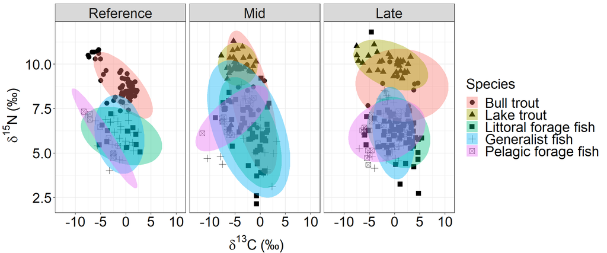

```r
#Plot Figure 1

ggplot(data,aes(x=d13C_corr, y=d15N_corr, shape=Functional_group))+
  facet_wrap(~Invasion_category,ncol=5)+
  geom_point(size = 3)+
  stat_ellipse(aes(x=d13C_corr, y=d15N_corr, fill=Functional_group),
               geom="polygon",
               alpha = 0.4, #transparency
               level = 0.95)+ #confidence interval
  theme_bw()+
  labs(x=expression(~delta^13*'C'~'(\211)'),
       y=expression(~delta^15*'N'~'(\211)'),
       fill = "Species",
       shape = "Species",
       group = "Species")+
  theme(axis.text = element_text(size = 20, color = "black"),
        axis.title.x = element_text(size = 20, vjust=-2),
        axis.title.y = element_text(size = 20, vjust=2),
        legend.text = element_text(size = 20),
        legend.title = element_text(size = 20),
        strip.text = element_text(size = 20))
```

### Figure 2, SEA.b, ellipse area in SIBER

This figure uses R package “SIBER” to calculate a posterior distribution of estimates of the isotopic dietary breadth population parameter.

```r
#https://cran.r-project.org/web/packages/SIBER/vignettes/Introduction-to-SIBER.html
#https://cran.r-project.org/web/packages/SIBER/vignettes/Ellipse-Overlap.html
#load data
isotope_dataset <- read.csv("C:/Users/wainr/Documents/nature_08132020/final_datasets/isotope_dataset_MT_lake_trout_food_web_11072020.csv", header=TRUE)
data <- subset(isotope_dataset,Sample_type=="Fish")

#prep data to meet siber specs
siber_df <- data[c("d13C_corr", "d15N_corr", "Functional_group", "Invasion_category")] #select siber's columns from full dataset
names(siber_df) <- c("iso1","iso2","group","community") #re-name columns to match siber
head(siber_df)
```

```
##        iso1     iso2               group community
## 2  -6.09375 10.29625          Bull trout Reference
## 6  -4.45375  9.42625          Bull trout Reference
## 8  -5.40375 10.82625          Bull trout Reference
## 13 -0.40375  5.22625     Generalist fish Reference
## 18 -7.17375  6.88625 Pelagic forage fish Reference
## 19 -7.15375  7.20625 Pelagic forage fish Reference
```

```r
siber_object <- createSiberObject(siber_df) #create siber object (the input for the mcmc)
group.ML <- groupMetricsML(siber_object) #calculate TA, SEA, SEA.c

# define siber mcmc model parameters
parms <- list()
parms$n.iter <- 2 * 10^4   # number of iterations to run the model
parms$n.burnin <- 1 * 10^3 # discard the first set of values
parms$n.thin <- 10     # thin the posterior by this many
parms$n.chains <- 2        # run this many chains

# define siber mcmc model priors
priors <- list()
priors$R <- 1 * diag(2) #uninformative
priors$k <- 2 #uninformative
priors$tau.mu <- 1.0E-3 #uninformative

#run siber mcmc
ellipses.posterior <- siberMVN(siber_object, parms, priors) #run the model


#calculate TA, SEA, SEAc for each group
group.ML <- groupMetricsML(siber_object) #ellipse area, NOT ellipse coordinates
#draw posteriors for siber ellipses for each group.community combination
SEA.B <- siberEllipses(ellipses.posterior) #motherlode
#SEA.B credible intervals:
cr.p <- c(0.95, 0.99) # vector of quantiles
#calculate credible intervals of SEA.B
SEA.B.credibles <- lapply(# call to hdrcde:hdr using lapply()
  as.data.frame(SEA.B),
  function(x,...){tmp<-hdrcde::hdr(x)$hdr},
  prob = cr.p) #vectors of the credible intervals for each group's sea.b

#siber has a built-in SEA.B plot: https://cran.r-project.org/web/packages/SIBER/vignettes/Introduction-to-SIBER.html
#but we'll re-do siberDensityPlot in ggplot

#draw posteriors for siber ellipses area for each group.community combination
SEA.B_2 <- SEA.B # copy siber's output list
colnames(SEA.B_2) <- colnames(group.ML) #re-name columns in new list
SEA.B_2 <- as.data.frame(SEA.B_2) #make dataframe from list
SEA.B_2 <- melt(SEA.B_2) #re-arrange variables in list
SEA.B_2$combo <- SEA.B_2$variable #re-name $combo (from melt()) into $variable, as required for separate()
SEA.B_2 <- separate(data = SEA.B_2,
                    col = variable,
                    into = c("invasion.category","Species"),
                    sep = "\\.",
                    extra = "merge") #use separate() to produce two useful columns
SEA.B_2$invasion.category <- factor(SEA.B_2$invasion.category,
                                    levels=c('Reference',
                                             'Mid',
                                             'Late')) #re-order variables

SEA.B_2$Species <- factor(SEA.B_2$Species,levels=c("Bull trout","Lake trout","Littoral forage fish","Generalist fish","Pelagic forage fish")) #re-order variables
```

```r
head(SEA.B_2)
```

```
##   invasion.category              Species    value
## 1              Late Littoral forage fish 13.18673
## 2              Late Littoral forage fish 10.65239
## 3              Late Littoral forage fish 11.50304
## 4              Late Littoral forage fish 11.21362
## 5              Late Littoral forage fish 11.38028
## 6              Late Littoral forage fish 10.29923
##                       combo
## 1 Late.Littoral forage fish
## 2 Late.Littoral forage fish
## 3 Late.Littoral forage fish
## 4 Late.Littoral forage fish
## 5 Late.Littoral forage fish
## 6 Late.Littoral forage fish
```

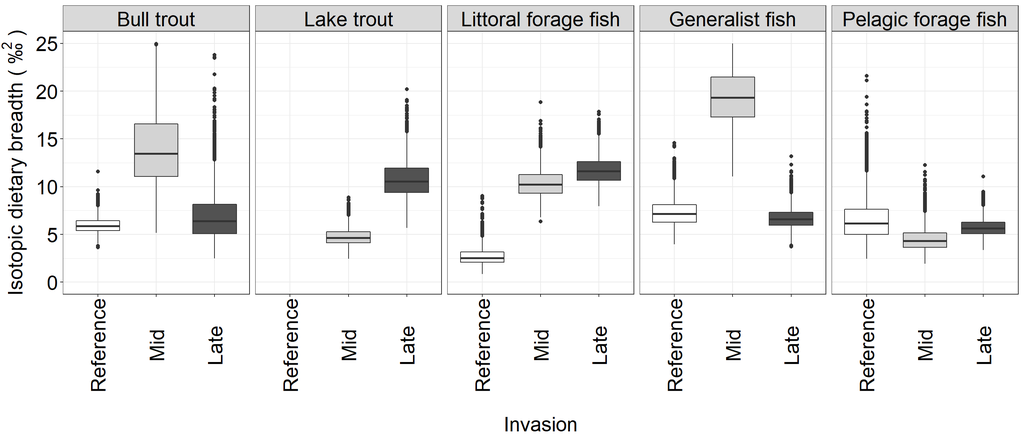

```r
#########################################################################################################
#Figure 2: SEA.b, ellipse area in SIBER
#########################################################################################################
library(ggplot2)
ggplot(data = SEA.B_2,
       aes(x=invasion.category, y=value, fill=invasion.category)) +
  geom_boxplot()+
  scale_fill_manual(values=c("white","light gray","grey32"))+
  theme_bw()+
  scale_y_continuous(limits=c(0,25))+
  labs(y = expression("Isotopic dietary breadth ( \211"^2~")"),
       x = "\nInvasion")+
  facet_wrap(~Species,
             ncol = 5)+
  theme(axis.text.x = element_text(size=20, angle = 90, color = "black", vjust=0.5),
        axis.text.y = element_text(size=20, color = "black"),
        axis.title.x = element_text(size=20),
        axis.title.y = element_text(size=20, vjust=3),
        legend.position = "none",
        strip.text = element_text(size=20, color = "black"))
```

### Figure 3, mixed effects linear modelling for $\delta$<sup>15</sup>N

The mixed effects models need to be done in two parts: 1) all fish other than lake trout 2) lake trout. There are no lake trout in reference lakes so we must run the models separately and then combine.

First, run the model for all fish besides lake trout.

```r
isotope_dataset <- read.csv("C:/Users/wainr/Documents/nature_08132020/final_datasets/isotope_dataset_MT_lake_trout_food_web_11072020.csv", header=TRUE)
data <- subset(isotope_dataset,Sample_type=="Fish")

#d15N model first part
data$Invasion_category <- factor(data$Invasion_category, levels= c("Reference","Mid","Late")) #re-order variables for plotting
data <- subset(data,real.name!="Lake trout") #must exclude lake trout because lake trout are not present in all invasion categories
head(subset(data, select=c(Lake_name,Invasion_category,Functional_group,d15N_corr)))
```

```
##     Lake_name Invasion_category    Functional_group d15N_corr
## 2  Big Salmon         Reference          Bull trout  10.29625
## 6  Big Salmon         Reference          Bull trout   9.42625
## 8  Big Salmon         Reference          Bull trout  10.82625
## 13 Big Salmon         Reference     Generalist fish   5.22625
## 18 Big Salmon         Reference Pelagic forage fish   6.88625
## 19 Big Salmon         Reference Pelagic forage fish   7.20625
```

```r
d15N_lmer <- lmer(d15N_corr ~ Invasion_category*Functional_group+ #predict d15N_corr for each unique combination of invasion category and functional group
                   (1|Lake_name), #lake is random effect
                 data=data)
#summary(d15N_lmer)
invasion <- predictorEffect("Invasion_category", d15N_lmer)#compute lmer results for plotting #https://www.rdocumentation.org/packages/effects/versions/4.2-0/topics/predictorEffects
invasion <- as.data.frame(invasion) #make results a dataframe for ggplot
```

Then run the second part of the model to generate lake trout results.

```r
#d15N model second part
data <- subset(isotope_dataset,Functional_group%in%c("Lake trout","Bull trout")) #now we include lake trout
data <- subset(data,Invasion_category != "Reference") #there are no lake trout in reference lakes
data$Invasion_category <- factor(data$Invasion_category, levels = c("Mid","Late")) #re-order variables
head(subset(data, select=c(Lake_name,Invasion_category,Functional_group,d15N_corr)))
```

```
##     Lake_name Invasion_category Functional_group d15N_corr
## 118    Bowman              Late       Lake trout     9.976
## 120    Bowman              Late       Lake trout     9.316
## 127    Bowman              Late       Lake trout    10.086
## 129    Bowman              Late       Lake trout    10.226
## 140    Bowman              Late       Bull trout     7.666
## 149    Bowman              Late       Lake trout     9.576
```

```r
d15N_lmer <- lmer(d15N_corr ~ Invasion_category*Functional_group+ #predict d15N_corr for each unique combination of invasion category and functional group
                   (1|Lake_name), #lake is random effect
                 data=data)

invasion2 <- predictorEffect("Invasion_category", d15N_lmer)#compute lmer results for plotting #https://www.rdocumentation.org/packages/effects/versions/4.2-0/topics/predictorEffects
invasion2 <- as.data.frame(invasion2) #make results a dataframe for ggplot
invasion2 <- subset(invasion2,Functional_group!="Bull trout")#exclude bull trout from invasion2 so we aren't duplicating
```

Finally, combine all results and plot.

```r
#combine parts 1 and 2
test <- rbind(invasion,invasion2)#combine
test$Functional_group <- factor(test$Functional_group, levels= c("Bull trout","Lake trout","Littoral forage fish","Generalist fish","Pelagic forage fish"))#re-order variables
test$Invasion_category <- factor(test$Invasion_category, levels= c("Reference","Mid","Late"))#re-order variables
head(test)
```

```
##   Invasion_category Functional_group      fit        se    lower    upper
## 1         Reference       Bull trout 9.188946 0.3242944 8.551209 9.826684
## 2               Mid       Bull trout 8.007583 0.4277699 7.166357 8.848809
## 3              Late       Bull trout 8.924386 0.4519365 8.035635 9.813137
## 4         Reference  Generalist fish 6.259648 0.3401872 5.590656 6.928639
## 5               Mid  Generalist fish 6.131686 0.3435947 5.455994 6.807378
## 6              Late  Generalist fish 6.159136 0.2910709 5.586734 6.731538
```

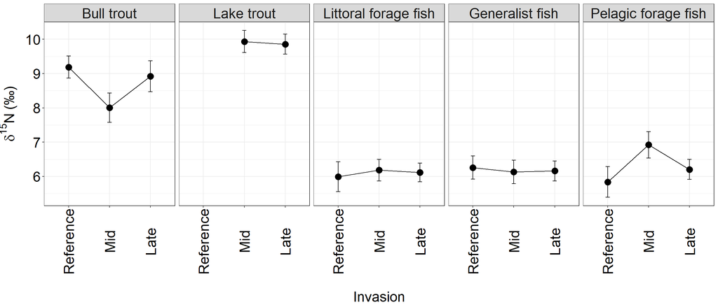

```r
#Plot figure 3
ggplot(test, aes (x= Invasion_category, y=fit, group=Functional_group))+
  geom_line()+
  geom_point(size = 4) +
  geom_errorbar(width=.1, aes(ymin=fit-se, ymax=fit+se)) +
  labs(y= expression(paste(delta^15, "N"~'(\211)')), x="\nInvasion")+
  facet_wrap(~Functional_group, ncol=5)+
  theme_bw()+
  theme(axis.text.x = element_text(size = 20, angle=90, color = "black", vjust=0.5),
        axis.text.y = element_text(size = 20, color = "black"),
        axis.title.y = element_text(size = 20, vjust = 4),
        axis.title.x = element_text(size = 20),
        legend.text = element_text(size = 15),
        legend.title = element_text(size = 15),
        strip.text = element_text(size = 20))
```

To generate p-values, cycle through each functional group, like this:

```r
#p-values for bull trout d15N
isotope_dataset <- read.csv("C:/Users/wainr/Documents/nature_08132020/final_datasets/isotope_dataset_MT_lake_trout_food_web_11072020.csv", header=TRUE)
data <- subset(isotope_dataset,Sample_type=="Fish")
data$Invasion_category <- factor(data$Invasion_category, levels= c("Reference","Mid","Late"))#re-order variables for plotting
data$Functional_group <- factor(data$Functional_group, levels= c("Bull trout","Generalist fish","Pelagic forage fish","Lake trout","Littoral forage fish")) #Produce p-value for the first factor in this list. Change the order of levels to generate each p-value.
data <- subset(data,real.name!="Lake trout")
d15N_lmer <- lmer(d15N_corr ~ Invasion_category*Functional_group+ #predict d15N_corr for each unique combination of invasion category and functional group
                   (1|Lake_name), #lake is random effect
                 data=data)
#summary(d15N_lmer) #bull trout d15N p-values comparing against Reference are from the model summary. Specifically, the Pr(>|t|) column and rows Invasion_categoryMid and Invasion_categoryLate.
```

```r
summary(d15N_lmer)[["coefficients"]][50] #p-value for Mid-invasion bull trout d15N compared to reference bull trout d15N
```

```
## [1] 0.04061689
```

```r
summary(d15N_lmer)[["coefficients"]][51] #p-value for Late-invasion bull trout d15N compared to reference bull trout d15N
```

```
## [1] 0.6381051
```

### Figure 4, mixed effects linear modelling for $\delta$<sup>13</sup>C

Like the $\delta$<sup>15</sup>Nd15N model, the $\delta$<sup>13</sup>C mixed effects models need to be done in two parts: 1) all fish other than lake trout 2) lake trout. There are no lake trout in reference lakes so we must run the models separately and then combine.

First, run the model for all fish besides lake trout.

```r
isotope_dataset <- read.csv("C:/Users/wainr/Documents/nature_08132020/final_datasets/isotope_dataset_MT_lake_trout_food_web_11072020.csv", header=TRUE)
data <- subset(isotope_dataset,Sample_type=="Fish")

#d13C model first part
data$Invasion_category <- factor(data$Invasion_category, levels= c("Reference","Mid","Late"))#re-order variables for plotting
data <- subset(data,real.name!="Lake trout") #must exclude lake trout because lake trout are not present in all invasion categories
head(subset(data, select=c(Lake_name,Invasion_category,Functional_group,d13C_corr)))
```

```
##     Lake_name Invasion_category    Functional_group d13C_corr
## 2  Big Salmon         Reference          Bull trout  -6.09375
## 6  Big Salmon         Reference          Bull trout  -4.45375
## 8  Big Salmon         Reference          Bull trout  -5.40375
## 13 Big Salmon         Reference     Generalist fish  -0.40375
## 18 Big Salmon         Reference Pelagic forage fish  -7.17375
## 19 Big Salmon         Reference Pelagic forage fish  -7.15375
```

```r
d13C_lmer <- lmer(d13C_corr ~ Invasion_category*Functional_group+ #predict d13Ccorr for each unique combination of invasion category and functional group
                   (1|Lake_name), #lake is random effect
                 data=data)
#summary(d13C_lmer)
invasion <- predictorEffect("Invasion_category", d13C_lmer)#compute lmer results for plotting #https://www.rdocumentation.org/packages/effects/versions/4.2-0/topics/predictorEffects
invasion <- as.data.frame(invasion) #make results a dataframe for ggplot
```

Then run the second part of the model to generate lake trout results.

```r
#d13C model second part
data <- subset(isotope_dataset,Functional_group%in%c("Lake trout","Bull trout")) #now we include lake trout
data <- subset(data,Invasion_category != "Reference") #there are no lake trout in reference lakes
data$Invasion_category <- factor(data$Invasion_category, levels = c("Mid","Late")) #re-order variables for plotting
head(subset(data, select=c(Lake_name,Invasion_category,Functional_group,d13C_corr)))
```

```
##     Lake_name Invasion_category Functional_group d13C_corr
## 118    Bowman              Late       Lake trout     0.466
## 120    Bowman              Late       Lake trout    -0.244
## 127    Bowman              Late       Lake trout     0.476
## 129    Bowman              Late       Lake trout     0.566
## 140    Bowman              Late       Bull trout     2.746
## 149    Bowman              Late       Lake trout     1.986
```

```r
d13C_lmer <- lmer(d13C_corr ~ Invasion_category*Functional_group+ #predict d13Ccorr for each unique combination of invasion category and functional group
                   (1|Lake_name), #lake is random effect
                 data=data)
#summary(d13C_lmer)#p-values
invasion2 <- predictorEffect("Invasion_category", d13C_lmer) #compute lmer results for plotting #https://www.rdocumentation.org/packages/effects/versions/4.2-0/topics/predictorEffects
invasion2 <-as.data.frame(invasion2) #make results a dataframe for ggplot
invasion2 <- subset(invasion2,Functional_group!="Bull trout")#exclude bull trout from invasion2 so we aren't duplicating
```

```r
#combine parts 1 and 2
test <- rbind(invasion,invasion2)
test$Functional_group <- factor(test$Functional_group, levels= c("Bull trout","Lake trout","Littoral forage fish","Generalist fish","Pelagic forage fish")) #re-order variables for plotting
test$Invasion_category <- factor(test$Invasion_category, levels= c("Reference","Mid","Late")) #re-order variables for plotting
head(test)
```

```
##   Invasion_category Functional_group        fit       se     lower
## 1         Reference       Bull trout -2.2555513 1.327209 -4.865560
## 2               Mid       Bull trout -1.8536192 1.435408 -4.676405
## 3              Late       Bull trout  0.3267549 1.344898 -2.318039
## 4         Reference  Generalist fish -2.3295019 1.340242 -4.965141
## 5               Mid  Generalist fish -1.9767422 1.343581 -4.618946
## 6              Late  Generalist fish -0.4603141 1.157020 -2.735639
##       upper
## 1 0.3544573
## 2 0.9691670
## 3 2.9715485
## 4 0.3061370
## 5 0.6654619
## 6 1.8150104
```

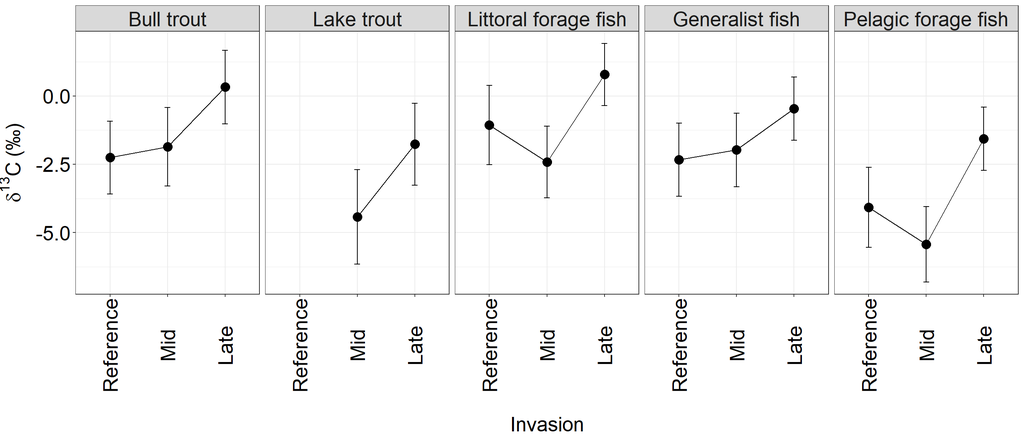

```r
#Plot figure 4
ggplot(test, aes (x= Invasion_category, y=fit, group=Functional_group))+
  geom_line()+
  geom_point(size = 4) +
  geom_errorbar(width=.1, aes(ymin=fit-se, ymax=fit+se)) +
  labs(y= expression(paste(delta^13, "C"~'(\211)')), x="\nInvasion")+
  facet_wrap(~Functional_group, ncol=5)+
  theme_bw()+
  theme(axis.text.x = element_text(size = 20, angle=90, color = "black", vjust=0.5),
        axis.text.y = element_text(size = 20, color = "black"),
        axis.title.y = element_text(size = 20, vjust = 4),
        axis.title.x = element_text(size = 20),
        legend.text = element_text(size = 15),
        legend.title = element_text(size = 15),
        strip.text = element_text(size = 20))
```

To generate p-values, cycle through each functional group, like this:

```r
#p-values for bull trout
rm(list=ls())
graphics.off()
set.seed(1)
isotope_dataset <- read.csv("C:/Users/wainr/Documents/nature_08132020/final_datasets/isotope_dataset_MT_lake_trout_food_web_11072020.csv", header=TRUE)
data <- subset(isotope_dataset,Sample_type=="Fish")
data$Invasion_category <- factor(data$Invasion_category, levels= c("Reference","Mid","Late"))
data$Functional_group <- factor(data$Functional_group, levels= c("Bull trout","Generalist fish","Pelagic forage fish","Lake trout","Littoral forage fish"))#Produce p-value for the first factor in this list. Change the order of levels to generate each p-value.
data <- subset(data,real.name!="Lake trout")
d13C_lmer <- lmer(d13C_corr ~ Invasion_category*Functional_group+
                   (1|Lake_name),
                 data=data)
#summary(d13C_lmer) #bull trout d13C p-values comparing against Reference are from the model summary. Specifically, the Pr(>|t|) column and rows Invasion_categoryMid and Invasion_categoryLate.
```

```r
summary(d13C_lmer)[["coefficients"]][50] #p-value for Mid-invasion bull trout d13C compared to reference bull trout d13C
```

```
## [1] 0.8416752
```

```r
summary(d13C_lmer)[["coefficients"]][51] #p-value for Late-invasion bull trout d13C compared to reference bull trout d13C
```

```
## [1] 0.2009179
```

### Figure 5, isotope niche overlap

This analysis uses R package “nicheROVER” to estimate diet overlap between bull trout and lake trout or vice versa in mid- and late-invasion lakes. Run the model separately for mid-invasion lakes and late-invasion lakes.

First, run the model for late-invasion lakes.

```r
rm(list=ls())
graphics.off()
set.seed(1)

#load data
isotope_dataset <- read.csv("C:/Users/wainr/Documents/nature_08132020/final_datasets/isotope_dataset_MT_lake_trout_food_web_11072020.csv", header=TRUE)
data <- subset(isotope_dataset,Sample_type=="Fish")

#STEP 1: RUN THIS SECTION FOR Invasion_category == Late

#prep data
nicheROVER_df <- subset(data, Invasion_category %in% "Late" & real.name %in% c("Bull trout","Lake trout")) #select Late blt and lkt
#eliminate all extra columns (nicheROVER requires only 3 columns as inputs)
nicheROVER_df <- nicheROVER_df[c("Functional_group","d13C_corr", "d15N_corr")] #columns must be in this order (species, d13C, d15N)
names(nicheROVER_df) <- c("species","D13C","D15N") #re-name columns to match nicherover
head(nicheROVER_df)
```

```
##        species   D13C   D15N
## 118 Lake trout  0.466  9.976
## 120 Lake trout -0.244  9.316
## 127 Lake trout  0.476 10.086
## 129 Lake trout  0.566 10.226
## 140 Bull trout  2.746  7.666
## 149 Lake trout  1.986  9.576
```

```r
#aggregate data as required for nicheROVER
aggregate(nicheROVER_df[2:3], nicheROVER_df[1], mean) #point estimates of mean isotope values

#create fish.par object
nsamples <- 1000
system.time({
  fish.par <- tapply(1:nrow(nicheROVER_df), nicheROVER_df$species, function(ii) niw.post(nsamples = nsamples,
                                                                                         X = nicheROVER_df[ii, 2:3]))
})
#remove NULLs from fish.par list
#fish.par should be a list of length = number of species (or whatever factor you're aggregating by)
#https://stackoverflow.com/questions/33004238/r-removing-null-elements-from-a-list
fish.par <- fish.par[-which(sapply(fish.par, is.null))] #get rid of NULLs from our fish.par list


#estimate niche overlaps
nsamples <- 1000

# Overlap calculation.  use nsamples = nprob = 10000 (1e4) for higher
# accuracy.  the variable over.stat can be supplied directly to the
# overlap.plot function

over.stat <- overlap(fish.par, nreps = nsamples, nprob = 1000, alpha = c(0.95,.99))

# The mean overlap metrics calculated across iteratations for both niche
# region sizes (alpha = .95 and alpha = .99) can be calculated and displayed
# in an array.
over.mean <- apply(over.stat,
                   c(1:2, 4),
                   mean) * 100
round(over.mean, 2)

over.cred <- apply(over.stat * 100,
                   c(1:2, 4),
                   quantile,
                   prob = c(0.025, 0.975),
                   na.rm = TRUE)
round(over.cred[, , , 1])  # display alpha = .95 niche region

#generate array of overlap probabilities for species A vs species B using over.mean and and over.cred
over.stat <- overlap(fish.par, nreps = nsamples, nprob = 1000, alpha = 0.95)

#re-do the package's plotting function to prep data for ggplot
over.hist <- apply(over.stat, 1:2, function(x) {
  if (any(is.na(x)))
    return(NULL)
  else {
    tmp <- x * 100
  }
  tmp
})
```

```r
#How much do bull trout overlap with lake trout?
data1<-as.data.frame(over.hist[[1,2]])#make dataframe from over.hist (the model's output)
colnames(data1)<-"Overlap"

#Add column to data1, add labels
BLT_Late <- data1
BLT_Late$Species <- "Bull trout"
BLT_Late$Invasion <- "Late"

head(BLT_Late)
```

```
##   Overlap    Species Invasion
## 1    89.9 Bull trout     Late
## 2    76.9 Bull trout     Late
## 3    80.8 Bull trout     Late
## 4    81.6 Bull trout     Late
## 5    66.4 Bull trout     Late
## 6    77.1 Bull trout     Late
```

```r
#How much do lake trout overlap bull trout?
data1<-as.data.frame(over.hist[[2,1]])#make dataframe from over.hist (the model's output)
colnames(data1)<-"Overlap"

#Add column to data1, label rows Late
LKT_Late <- data1
LKT_Late$Species <- "Lake trout"
LKT_Late$Invasion <- "Late"

head(LKT_Late)
```

```
##   Overlap    Species Invasion
## 1    38.5 Lake trout     Late
## 2    38.5 Lake trout     Late
## 3    71.6 Lake trout     Late
## 4    55.6 Lake trout     Late
## 5    57.1 Lake trout     Late
## 6    61.6 Lake trout     Late
```

Next, run the same model for mid-invasion lakes.

```r
#STEP 2: RUN THIS SECTION FOR Invasion_category == Mid

#prep data
nicheROVER_df <- subset(data, Invasion_category %in% "Mid" & real.name %in% c("Bull trout","Lake trout")) #select Mid blt and lkt #select blt and lkt
#eliminate all extra columns (nicheROVER requires only 3 columns as inputs)
nicheROVER_df <- nicheROVER_df[c("Functional_group","d13C_corr", "d15N_corr")] #columns must be in this order (species, d13C, d15N)
names(nicheROVER_df) <- c("species","D13C","D15N") #re-name columns to match nicherover

#aggregate data as required for nicheROVER
aggregate(nicheROVER_df[2:3], nicheROVER_df[1], mean) #point estimates of mean isotope values

#create fish.par object
nsamples <- 1000
system.time({
  fish.par <- tapply(1:nrow(nicheROVER_df), nicheROVER_df$species, function(ii) niw.post(nsamples = nsamples,
                                                                                         X = nicheROVER_df[ii, 2:3]))
})
#remove NULLs from fish.par list
#fish.par should be a list of length = number of species (or whatever factor you're aggregating by)
#https://stackoverflow.com/questions/33004238/r-removing-null-elements-from-a-list
fish.par <- fish.par[-which(sapply(fish.par, is.null))] #get rid of NULLs from our fish.par list


#estimate niche overlaps
nsamples <- 1000

# Overlap calculation.  use nsamples = nprob = 10000 (1e4) for higher
# accuracy.  the variable over.stat can be supplied directly to the
# overlap.plot function

over.stat <- overlap(fish.par, nreps = nsamples, nprob = 1000, alpha = c(0.95,.99))

# The mean overlap metrics calculated across iteratations for both niche
# region sizes (alpha = .95 and alpha = .99) can be calculated and displayed
# in an array.
over.mean <- apply(over.stat,
                   c(1:2, 4),
                   mean) * 100
round(over.mean, 2)

over.cred <- apply(over.stat * 100,
                   c(1:2, 4),
                   quantile,
                   prob = c(0.025, 0.975),
                   na.rm = TRUE)
round(over.cred[, , , 1])  # display alpha = .95 niche region

#generate array of overlap probabilities for species A vs species B using over.mean and and over.cred
over.stat <- overlap(fish.par, nreps = nsamples, nprob = 1000, alpha = 0.95)

#re-do the package's plotting function to prep data for ggplot
over.hist <- apply(over.stat, 1:2, function(x) {
  if (any(is.na(x)))
    return(NULL)
  else {
    tmp <- x * 100
  }
  tmp
})
```

```r
#How much do bull trout overlap with lake trout?
data1<-as.data.frame(over.hist[[1,2]])#make dataframe from over.hist (the model's output)
colnames(data1)<-"Overlap"

#Add column to data1, label rows Late
BLT_Mid <- data1
BLT_Mid$Species <- "Bull trout"
BLT_Mid$Invasion <- "Mid"
head(BLT_Mid)
```

```
##   Overlap    Species Invasion
## 1    30.9 Bull trout      Mid
## 2    22.0 Bull trout      Mid
## 3    52.4 Bull trout      Mid
## 4    33.3 Bull trout      Mid
## 5    28.6 Bull trout      Mid
## 6    31.6 Bull trout      Mid
```

```r
#How much do lake trout overlap bull trout?
data1<-as.data.frame(over.hist[[2,1]])#make dataframe from over.hist (the model's output)
colnames(data1)<-"Overlap"

#Add column to data1, label rows Late
LKT_Mid <- data1
LKT_Mid$Species <- "Lake trout"
LKT_Mid$Invasion <- "Mid"
head(LKT_Mid)
```

```
##   Overlap    Species Invasion
## 1    80.0 Lake trout      Mid
## 2    64.6 Lake trout      Mid
## 3    82.1 Lake trout      Mid
## 4    92.0 Lake trout      Mid
## 5    81.2 Lake trout      Mid
## 6    67.5 Lake trout      Mid
```

Then, combine results for mid-invasion and late-invasion lake results:

```r
BLT_both <- rbind(BLT_Mid,BLT_Late) #combine BLT rows
LKT_both <- rbind(LKT_Mid,LKT_Late) #combine LKT rows
#or
Mid_both <- rbind(BLT_Mid,LKT_Mid) #combine mid rows
Late_both <- rbind(BLT_Late,LKT_Late) #combine late rows
```

Then, plot comparisons:

```r
#BLT_plot
BLT_both$Invasion <- factor(BLT_both$Invasion, levels=c("Mid","Late")) #re-order variables
head(BLT_both)
```

```
##   Overlap    Species Invasion
## 1    30.9 Bull trout      Mid
## 2    22.0 Bull trout      Mid
## 3    52.4 Bull trout      Mid
## 4    33.3 Bull trout      Mid
## 5    28.6 Bull trout      Mid
## 6    31.6 Bull trout      Mid
```

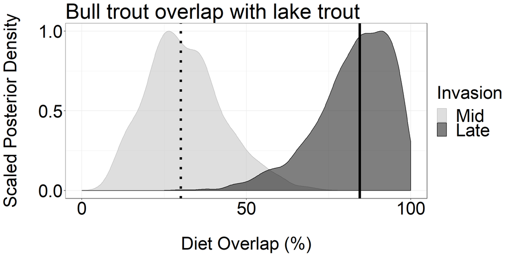

```r
ggplot(data=BLT_both, aes(x=Overlap,y=..scaled.., fill=Invasion, color = Invasion))+
  geom_density(alpha=0.5)+
  scale_fill_manual(values=c("gray","black"))+
  scale_color_manual(values=c("gray","black"))+
  scale_x_continuous(limits=c(0,100),breaks=c(0,50,100))+ #for percent instead of proportional overlap
  scale_y_continuous(limits=c(0,1),breaks=c(0,0.5,1))+
  labs(title="Bull trout overlap with lake trout",
       x="\nDiet Overlap (%)",
       y="Scaled Posterior Density\n",
       fill="Invasion")+
  theme_bw()+
  geom_vline(xintercept = quantile(subset(BLT_both,BLT_both$Invasion=="Late")$Overlap, prob = 0.5), linetype="solid", size=2)+ #Late
  geom_vline(xintercept = quantile(subset(BLT_both,BLT_both$Invasion=="Mid")$Overlap, prob = 0.5), linetype="dotted", size=2)+ #Mid
  theme(axis.text = element_text(size = 30, color = "black"),
    axis.title = element_text(size = 30, color = "black"),
    title = element_text(size=30),
    legend.text = element_text(size=30))
```

```r
#LKT_plot
LKT_both$Invasion <- factor(LKT_both$Invasion, levels=c("Mid","Late")) #re-order variables
head(LKT_both)
```

```
##   Overlap    Species Invasion
## 1    80.0 Lake trout      Mid
## 2    64.6 Lake trout      Mid
## 3    82.1 Lake trout      Mid
## 4    92.0 Lake trout      Mid
## 5    81.2 Lake trout      Mid
## 6    67.5 Lake trout      Mid
```

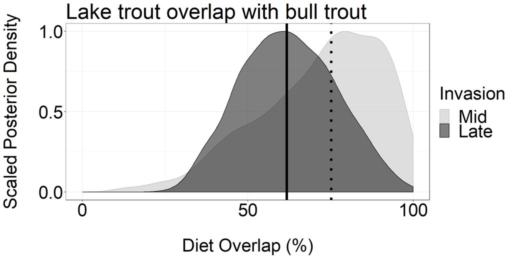

```r
ggplot(data=LKT_both, aes(x=Overlap,y=..scaled.., fill=Invasion, color = Invasion))+
  geom_density(alpha=0.5)+
  scale_fill_manual(values=c("gray","black"))+
  scale_color_manual(values=c("gray","black"))+
  scale_x_continuous(limits=c(0,100),breaks=c(0,50,100))+ #for percent instead of proportional overlap
  scale_y_continuous(limits=c(0,1),breaks=c(0,0.5,1))+
  labs(title="Lake trout overlap with bull trout",
       x="\nDiet Overlap (%)",
       y="Scaled Posterior Density\n",
       fill="Invasion")+
  theme_bw()+
  geom_vline(xintercept = quantile(subset(LKT_both,LKT_both$Invasion=="Late")$Overlap, prob = 0.5), linetype="solid", size=2)+ #Late
  geom_vline(xintercept = quantile(subset(LKT_both,LKT_both$Invasion=="Mid")$Overlap, prob = 0.5), linetype="dotted", size=2)+ #Mid
  theme(axis.text = element_text(size = 30, color="black"),
    axis.title = element_text(size = 30, color = "black"),
    title = element_text(size=30),
    legend.text = element_text(size=30))
```

# SI Table 4

Finally, produce a summary table for the niche overlap outputs:

```r
#Produce SI Table 4
ls_SI_4 <- vector(mode = "list")
#BLT Mid
ls_SI_4$BLT_in_LKT$Mid$CrI_2.5 <- quantile(subset(Mid_both,Mid_both$Species=="Bull trout")$Overlap, prob = 0.025)
ls_SI_4$BLT_in_LKT$Mid$CrI_50 <- quantile(subset(Mid_both,Mid_both$Species=="Bull trout")$Overlap, prob = 0.5)
ls_SI_4$BLT_in_LKT$Mid$Mean <- mean(subset(Mid_both,Mid_both$Species=="Bull trout")$Overlap)
ls_SI_4$BLT_in_LKT$Mid$CrI_97.5 <- quantile(subset(Mid_both,Mid_both$Species=="Bull trout")$Overlap, prob = 0.975)
#BLT Late
ls_SI_4$BLT_in_LKT$Late$CrI_2.5 <- quantile(subset(Late_both,Mid_both$Species=="Bull trout")$Overlap, prob = 0.025)
ls_SI_4$BLT_in_LKT$Late$CrI_50 <- quantile(subset(Late_both,Mid_both$Species=="Bull trout")$Overlap, prob = 0.5)
ls_SI_4$BLT_in_LKT$Late$Mean <- mean(subset(Late_both,Late_both$Species=="Bull trout")$Overlap)
ls_SI_4$BLT_in_LKT$Late$CrI_97.5 <- quantile(subset(Late_both,Late_both$Species=="Bull trout")$Overlap, prob = 0.975)
#LKT Mid
ls_SI_4$LKT_in_BLT$Mid$CrI_2.5 <- quantile(subset(Mid_both,Mid_both$Species=="Lake trout")$Overlap, prob = 0.025)
ls_SI_4$LKT_in_BLT$Mid$CrI_50 <- quantile(subset(Mid_both,Mid_both$Species=="Lake trout")$Overlap, prob = 0.5)
ls_SI_4$LKT_in_BLT$Mid$Mean <- mean(subset(Mid_both,Mid_both$Species=="Lake trout")$Overlap)
ls_SI_4$LKT_in_BLT$Mid$CrI_97.5 <- quantile(subset(Mid_both,Mid_both$Species=="Lake trout")$Overlap, prob = 0.975)
#LKT Late
ls_SI_4$LKT_in_BLT$Late$CrI_2.5 <- quantile(subset(Late_both,Mid_both$Species=="Lake trout")$Overlap, prob = 0.025)
ls_SI_4$LKT_in_BLT$Late$CrI_50 <- quantile(subset(Late_both,Mid_both$Species=="Lake trout")$Overlap, prob = 0.5)
ls_SI_4$LKT_in_BLT$Late$Mean <- mean(subset(Late_both,Late_both$Species=="Lake trout")$Overlap)
ls_SI_4$LKT_in_BLT$Late$CrI_97.5 <- quantile(subset(Late_both,Mid_both$Species=="Lake trout")$Overlap, prob = 0.975)

stats <- c("Cr_2.5_mid","Cr_50_mid","Mean_mid","Cr_97.5_mid","Cr_2.5_late","Cr_50_late","Mean_late","Cr_97.5_late")
overlaps <- c("BLT_in_LKT","LKT_in_BLT")

SI_4<-data.frame(matrix(unlist(ls_SI_4), #make a dataframe out of the list ls_SI_4
                        nrow=length(overlaps), #one row for each overlap
                        byrow=T),
                 stringsAsFactors=FALSE)
row.names(SI_4) <- overlaps
colnames(SI_4) <- stats
SI_4 <- round(SI_4,1)
library(knitr)
kable(SI_4, align="cccccccc", caption = "Table 6. Summary of isotope niche overlap between lake trout and bull trout in mid- and late-invasion lakes (Article SI Table 4).")
```

Table 6. Summary of isotope niche overlap between lake trout and bull trout in mid- and late-invasion lakes (Article SI Table 4).

|  | Cr_2.5_mid | Cr_50_mid | Mean_mid | Cr_97.5_mid | Cr_2.5_late | Cr_50_late | Mean_late | Cr_97.5_late |
| --- | --- | --- | --- | --- | --- | --- | --- | --- |
| BLT_in_LKT | 11.5 | 30.1 | 31.4 | 57.2 | 55.1 | 84.5 | 82.7 | 98.3 |
| LKT_in_BLT | 32.6 | 75.2 | 72.1 | 97.7 | 35.9 | 61.8 | 62.3 | 90.2 |

# Figure 7, conversion

Conversion uses long-term lake trout and bull trout abundance data to predict the timing of lake trout invasion and persistence of bull trout. Given generic binomial linear form (below), we need R to solve for coefficients ${\beta_0}$ and $\beta$, given lake trout and bull trout abundance data.

$$Predicted~conversion = \hat{y} = \frac{1}{1+e^{-(\beta_0+\beta\cdot~x)}}$$
To solve for ${\beta_0}$ and $\beta$, we use binomial linear regression.

```r
rm(list=ls())
graphics.off()
set.seed(1)

data <- read.csv("C:/Users/wainr/Documents/nature_08132020/final_datasets/conversion_09302020_2.csv", header=TRUE)
data$conv <- data$LKT/(data$LKT+data$BLT) #calculate empirical conversion for each survey record
data$timestep <- data$year-1969 #calculate timestep for each survey year. 1969 is earliest survey year.
tail(data)
```

```
##      Lake year LKT BLT      conv timestep
## 20 Kintla 1977  18  12 0.6000000        8
## 21 Kintla 2000  45   2 0.9574468       31
## 22 Kintla 2005  34  12 0.7391304       36
## 23 Kintla 2010  32   3 0.9142857       41
## 24 Kintla 2015  53   4 0.9298246       46
## 25 Kintla 2019  44   1 0.9777778       50
```

```r
conv_lm <- glm(conv ~ timestep, data = data, family = binomial) #lm using timestep
#conv_lm2 <- glm(conv ~ year, data = data, family = binomial) #lm using year
summary(conv_lm) #Estimates of (Intercept) and timestep are the binomial linear regression coefficients.
```

```
##
## Call:
## glm(formula = conv ~ timestep, family = binomial, data = data)
##
## Deviance Residuals:
##      Min        1Q    Median        3Q       Max
## -0.71197  -0.23585  -0.02285   0.18210   0.80790
##
## Coefficients:
##             Estimate Std. Error z value Pr(>|z|)
## (Intercept) -1.97331    1.04164  -1.894  0.05817 .
## timestep     0.09127    0.03329   2.741  0.00612 **
## ---
## Signif. codes:  0 '***' 0.001 '**' 0.01 '*' 0.05 '.' 0.1 ' ' 1
##
## (Dispersion parameter for binomial family taken to be 1)
##
##     Null deviance: 15.0304  on 24  degrees of freedom
## Residual deviance:  3.8922  on 23  degrees of freedom
## AIC: 16.29
##
## Number of Fisher Scoring iterations: 5
```

Specifically,${\beta_0}$ is

```r
summary(conv_lm)[["coefficients"]][1]
```

```
## [1] -1.973312
```

and ${\beta}$ is

```r
summary(conv_lm)[["coefficients"]][2]
```

```
## [1] 0.0912652
```

Producing this:
$$Predicted~conversion = \hat{y} = \frac{1}{1+e^{-(-1.97+0.091\cdot~x)}}$$
Then, check the model’s fit:

```r
library(rsq)
rsq(conv_lm) #r-squared
```

```
## [1] 0.8139752
```

Finally, plot empirical and predicted conversion versus time:

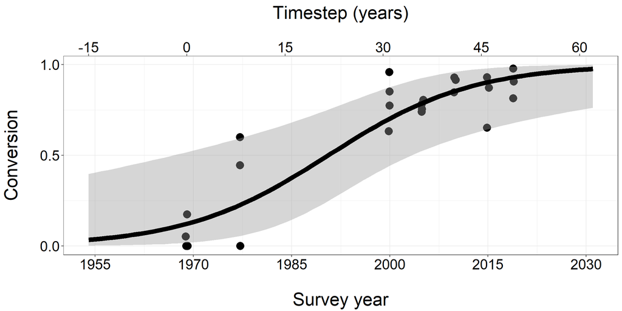

```r
#Figure 7 (both timestep and year)
ggplot(data = data, aes(x = year,y = conv))+
  geom_jitter(width = 0.2, height = 0, size = 5)+
  stat_smooth(method = "glm",
              method.args = list(family = "binomial"),
              se = TRUE,
              size = 3,
              color = "black",
              fullrange = TRUE)+ #extend prediction beyond empirical data
  theme_bw()+
  labs(y = "Conversion\n")+
  scale_y_continuous(breaks = c(0,0.5,1))+
  scale_x_continuous(name = "\nSurvey year",
                     breaks = c(1955,1970,1985,2000,2015,2030),
                     limits = c(1954,2031),
                     sec.axis = sec_axis(trans = ~.-1969, #1969 is the first survey year
                                       name = "Timestep (years)\n",
                                       breaks = c(-15,0,15,30,45,60)))+
  theme(axis.text.x = element_text(size = 20, color = "black"),
        axis.text.y = element_text(size = 20, color = "black"),
        axis.title.x = element_text(size = 25),
        axis.title.y = element_text(size = 25),
        plot.title = element_text(size = 29))
```

# Figure 8, NMDS ordination for littoral macroinvertebrates

We used non-metric dimensional scaling ordination to measure differences in macroinvertebrate communities among lake trout invasion categories.

```r
#load data
data <- read.csv("C:/Users/wainr/Documents/nature_08132020/final_datasets/transect_data.csv", header=TRUE)
head(data[,1:5])
```

```
##   Lake_transect Aeshnidae Amphipoda Asellidae Baetidae
## 1   Big Salmon1         0        12         0        0
## 2   Big Salmon2         0        16         0        2
## 3   Big Salmon3         0        22         0        0
## 4   Big Salmon4         0        19         0        0
## 5   Big Salmon5         0        19         0        0
## 6   Big Salmon6         0        14         0        0
```

```r
lake <- read.csv("C:/Users/wainr/Documents/nature_08132020/final_datasets/lake_data.csv", header=TRUE)
head(lake)
```

```
##    Lake_name Lake_transect Invasion_category Timestep_years
## 1 Big Salmon   Big Salmon1         Reference              0
## 2 Big Salmon   Big Salmon2         Reference              0
## 3 Big Salmon   Big Salmon3         Reference              0
## 4 Big Salmon   Big Salmon4         Reference              0
## 5 Big Salmon   Big Salmon5         Reference              0
## 6 Big Salmon   Big Salmon6         Reference              0
```

```r
#community statistics
lake$richness<-rowSums(data[,2:48] > 0) #richness
lake$div<-diversity(data[,2:48]) #diversity
lake$even<-lake$div/log(lake$richness) #evenness
lake$abundance<-rowSums(data[,2:48]) #abundance
species<-data[,2:48]

#calculate nmds scores for communities
nms<-metaMDS(species, k=3)
```

```
## Square root transformation
## Wisconsin double standardization
## *** No convergence -- monoMDS stopping criteria:
##      2: no. of iterations >= maxit
##     18: stress ratio > sratmax
```

```r
nms[["stress"]] #ordination stress (goodness of fit) #http://strata.uga.edu/8370/handouts/nmsTutorial.pdf
```

```
## [1] 0.1813075
```

```r
#permanova for p-value Pr(>F)
adonis(species~Invasion_category, data = lake)
```

```
##
## Call:
## adonis(formula = species ~ Invasion_category, data = lake)
##
## Permutation: free
## Number of permutations: 999
##
## Terms added sequentially (first to last)
##
##                   Df SumsOfSqs MeanSqs F.Model      R2 Pr(>F)
## Invasion_category  2    2.7986 1.39931  6.3177 0.17396  0.001 ***
## Residuals         60   13.2894 0.22149         0.82604
## Total             62   16.0880                 1.00000
## ---
## Signif. codes:  0 '***' 0.001 '**' 0.01 '*' 0.05 '.' 0.1 ' ' 1
```

```r
p_value <- adonis(species~Invasion_category, data = lake)
p_value[["aov.tab"]][["Pr(>F)"]]
```

```
## [1] 0.001    NA    NA
```

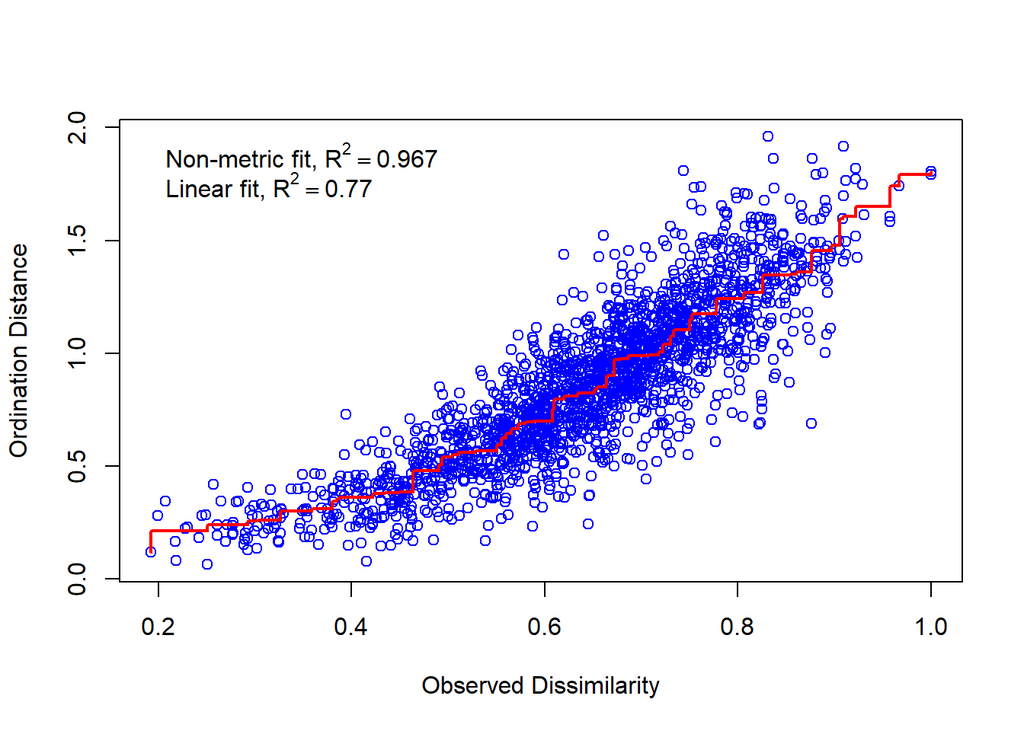

```r
#stressplot
stressplot(nms)
```

```r
#prep nmds scores for plotting
#ordisurf example: https://chrischizinski.github.io/rstats/ordisurf/
#ordisurf example: https://oliviarata.wordpress.com/2014/07/17/ordinations-in-ggplot2-v2-ordisurf/
ordi <- ordisurf(nms ~ lake$Timestep_years) #create the ordisurf object
```

```r
ordi.grid <- ordi$grid #extracts the ordisurf object
str(ordi.grid) #it's a list though - cannot be plotted as is
ordi.lake <- expand.grid(x = ordi.grid$x, y = ordi.grid$y) #get x and ys
ordi.lake$z <- as.vector(ordi.grid$z) #unravel the matrix for the z scores
ordi.lake.na <- data.frame(na.omit(ordi.lake)) #gets rid of the nas
ordi.lake.na #looks ready for plotting!
lake.NMDS.data <- lake #Copy lake data, so we can add nms scores. there are other ways of doing this. But this is the way I do it for ease of plotting
lake.NMDS.data$NMDS1 <- nms$points[ ,1] #put the NMDS scores for the plots into a lake dataframe. you could put them into the existing one if you preferred.
lake.NMDS.data$NMDS2 <- nms$points[ ,2]

lake.NMDS.data$Invasion_category <- factor(lake.NMDS.data$Invasion_category,
                                   levels=c('Reference',
                                            'Mid',
                                            'Late')) #re-order variables
```

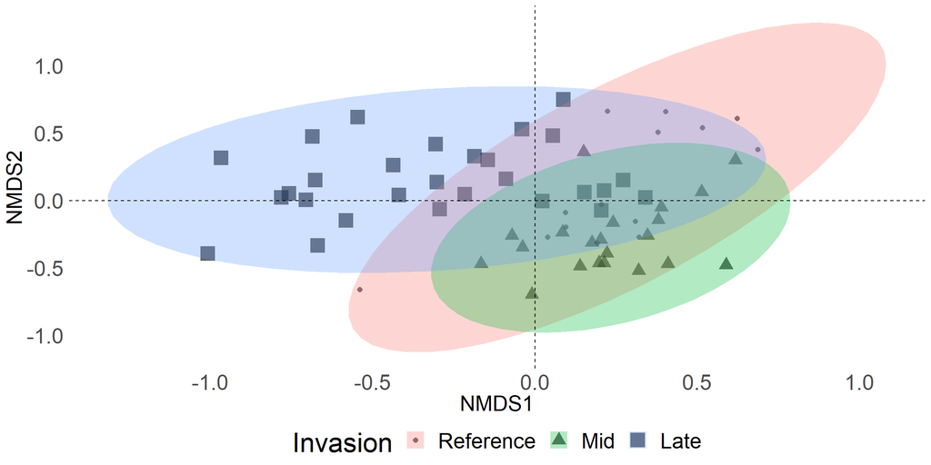

```r
ggplot(lake.NMDS.data, aes(x = NMDS1, y = NMDS2))+
  geom_point(aes(shape = Invasion_category, size=Invasion_category), alpha = 0.6)+ #plots the NMDS points, with shape by invasion
  theme_minimal() + #for aesthetics
  stat_ellipse(aes(x=NMDS1, y=NMDS2, group=Invasion_category, fill = Invasion_category),
               type = "norm",
               geom = "polygon",
               alpha = 0.3,
               level = 0.95)+
  labs(shape = "Invasion", size="Invasion", group="Invasion", fill="Invasion")+#another way to set the labels, in this case, for the color legend
  geom_hline(yintercept=0, linetype="dashed")+
  geom_vline(xintercept=0, linetype="dashed")+
  theme(legend.key = element_blank(),  #removes the box around each legend item
        legend.position = "bottom", #legend at the bottom
        legend.direction = "horizontal",
        legend.box = "horizontal",
        legend.box.just = "centre",
        axis.text.x = element_text(size=20),
        axis.text.y = element_text(size=20),
        axis.title.x = element_text(size=20),
        axis.title.y = element_text(size=20),
        plot.title = element_text(size=30),
        legend.text = element_text(size=20),
        legend.title = element_text(size=25),
        panel.background = element_blank(),
        panel.grid.major = element_blank(),  #remove major-grid labels
        panel.grid.minor = element_blank(),  #remove minor-grid labels
        plot.background = element_blank())
```

# Bibliography

Post, D. M. Using stable isotopes to estimate trophic position: models, methods, and assumptions. Ecology 83, 703-718 (2002).  
Guzzo, M. M., Haffner, G. D., Sorge, S., Rush, S. A. & Fisk, A. T. Spatial and temporal variabilities of $\delta$<sup>13</sup>C and $\delta$<sup>15</sup>N within lower trophic levels of a large lake: implications for estimating trophic relationships of consumers. Hydrobiologia 675, 41-53 (2011).  
Hobson, K. A., Ofukany, A., Soto, D. X. & Wassenaar, L. I. An isotopic baseline ($\delta$<sup>13</sup>C, $\delta$<sup>15</sup>N) for fishes of Lake Winnipeg: Implications for investigating impacts of eutrophication and invasive species. Journal of Great Lakes Research 38, 58-65 (2012).